### Question 0

- Draw a concepts diagram that uses all the following Github terminology
  - Include any missing keywords that will simplify the concepts diagrams

`Push`, `Repository`, `Clone`, `Pull`, `Pull Request`, `Branch`, `Merging`, `Github Client`, `README file`, `Private or Public`

```r
# The concept of github diagram is presented below
```

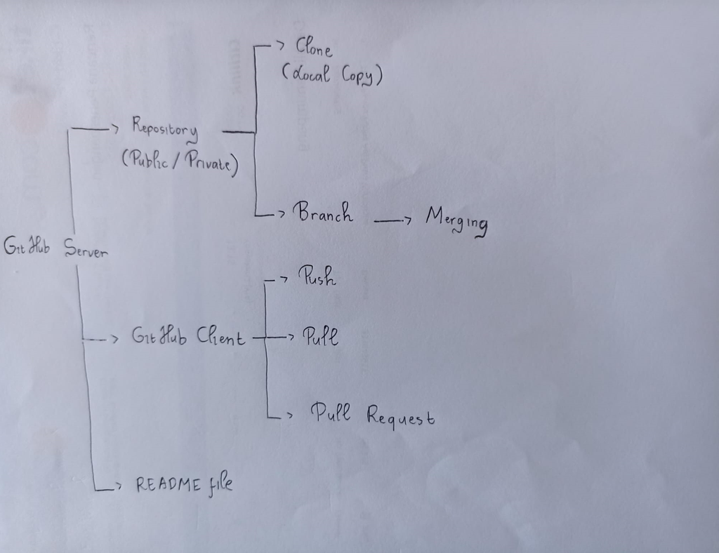

#### Question 1

`matrix(c(1,2,3,4,5,6) , nrow = 3)`

- Running the expression produces the following matrix

| 1 | 4 |
| --- | --- |
| 2 | 5 |
| 3 | 6 |

- How can you modify the call to `matrix()` to produce the following matrix instead?

|  | col_1 | col_2 |
| --- | --- | --- |
| row_1 | 1 | 2 |
| row_2 | 3 | 4 |
| row_3 | 5 | 6 |

- Note that you need to name the columns (col_1 and col_2) and name the rows (row_1, row_2, row_3)

Hint: Use the `?` symbol to invoke the matrix documentation

```r
matrix(c(1, 2, 3, 4, 5, 6), nrow = 3)
```

```
##      [,1] [,2]
## [1,]    1    4
## [2,]    2    5
## [3,]    3    6
```

```r
matrix(c(1, 2, 3, 4, 5, 6), nrow = 3, dimnames = list(c("row_1", "row_2", "row_3"), c("col_1", "col_2")))
```

```
##       col_1 col_2
## row_1     1     4
## row_2     2     5
## row_3     3     6
```

#### Question 1

`matrix(c(1,2,3,4,5,6) , nrow = 3)`

- Running the expression produces the following matrix

| 1 | 4 |
| --- | --- |
| 2 | 5 |
| 3 | 6 |

- How can you modify the call to `matrix()` to produce the following matrix instead?

|  | col_1 | col_2 |
| --- | --- | --- |
| row_1 | 1 | 2 |
| row_2 | 3 | 4 |
| row_3 | 5 | 6 |

- Note that you need to name the columns (col_1 and col_2) and name the rows (row_1, row_2, row_3)

Hint: Use the `?` symbol to invoke the matrix documentation

```r
matrix(c(1, 2, 3, 4, 5, 6), nrow = 3)
```

```
##      [,1] [,2]
## [1,]    1    4
## [2,]    2    5
## [3,]    3    6
```

```r
matrix(c(1, 2, 3, 4, 5, 6), nrow = 3, dimnames = list(c("row_1", "row_2", "row_3"), c("col_1", "col_2")))
```

```
##       col_1 col_2
## row_1     1     4
## row_2     2     5
## row_3     3     6
```

#### Question 2

- Load then sort the airquality data frame on its `Temp` and `Solar.R` columns in reverse order (largest to smallest values)
  - The function to sort a data frame is called order
- Display only the first 15 lines of your table

```r
data("airquality")
airquality
```

```
##     Ozone Solar.R Wind Temp Month Day
## 1      41     190  7.4   67     5   1
## 2      36     118  8.0   72     5   2
## 3      12     149 12.6   74     5   3
## 4      18     313 11.5   62     5   4
## 5      NA      NA 14.3   56     5   5
## 6      28      NA 14.9   66     5   6
## 7      23     299  8.6   65     5   7
## 8      19      99 13.8   59     5   8
## 9       8      19 20.1   61     5   9
## 10     NA     194  8.6   69     5  10
## 11      7      NA  6.9   74     5  11
## 12     16     256  9.7   69     5  12
## 13     11     290  9.2   66     5  13
## 14     14     274 10.9   68     5  14
```

[output cut: 139 more lines]

```r
sorted_airquality_temp<-airquality[order(-airquality$Temp),]
sorted_airquality_temp
```

```
##     Ozone Solar.R Wind Temp Month Day
## 120    76     203  9.7   97     8  28
## 122    84     237  6.3   96     8  30
## 121   118     225  2.3   94     8  29
## 123    85     188  6.3   94     8  31
## 42     NA     259 10.9   93     6  11
## 126    73     183  2.8   93     9   3
## 127    91     189  4.6   93     9   4
## 43     NA     250  9.2   92     6  12
## 69     97     267  6.3   92     7   8
## 70     97     272  5.7   92     7   9
## 102    NA     222  8.6   92     8  10
## 125    78     197  5.1   92     9   2
## 75     NA     291 14.9   91     7  14
## 124    96     167  6.9   91     9   1
```

[output cut: 139 more lines]

```r
sorted_airquality_solar.R<-airquality[order(-airquality$Solar.R),]
sorted_airquality_solar.R
```

```
##     Ozone Solar.R Wind Temp Month Day
## 16     14     334 11.5   64     5  16
## 45     NA     332 13.8   80     6  14
## 41     39     323 11.5   87     6  10
## 19     30     322 11.5   68     5  19
## 46     NA     322 11.5   79     6  15
## 22     11     320 16.6   73     5  22
## 67     40     314 10.9   83     7   6
## 4      18     313 11.5   62     5   4
## 17     34     307 12.0   66     5  17
## 7      23     299  8.6   65     5   7
## 84     NA     295 11.5   82     7  23
## 85     80     294  8.6   86     7  24
## 40     71     291 13.8   90     6   9
## 75     NA     291 14.9   91     7  14
```

[output cut: 139 more lines]

```r
sorted_airquality_temp_solar.R <- airquality[order(-airquality$Temp,-airquality$Solar.R),]
sorted_airquality_temp_solar.R
```

```
##     Ozone Solar.R Wind Temp Month Day
## 120    76     203  9.7   97     8  28
## 122    84     237  6.3   96     8  30
## 121   118     225  2.3   94     8  29
## 123    85     188  6.3   94     8  31
## 42     NA     259 10.9   93     6  11
## 127    91     189  4.6   93     9   4
## 126    73     183  2.8   93     9   3
## 70     97     272  5.7   92     7   9
## 69     97     267  6.3   92     7   8
## 43     NA     250  9.2   92     6  12
## 102    NA     222  8.6   92     8  10
## 125    78     197  5.1   92     9   2
## 75     NA     291 14.9   91     7  14
## 124    96     167  6.9   91     9   1
```

[output cut: 139 more lines]

```r
head(sorted_airquality_temp_solar.R,15)
```

```
##     Ozone Solar.R Wind Temp Month Day
## 120    76     203  9.7   97     8  28
## 122    84     237  6.3   96     8  30
## 121   118     225  2.3   94     8  29
## 123    85     188  6.3   94     8  31
## 42     NA     259 10.9   93     6  11
## 127    91     189  4.6   93     9   4
## 126    73     183  2.8   93     9   3
## 70     97     272  5.7   92     7   9
## 69     97     267  6.3   92     7   8
## 43     NA     250  9.2   92     6  12
## 102    NA     222  8.6   92     8  10
## 125    78     197  5.1   92     9   2
## 75     NA     291 14.9   91     7  14
## 124    96     167  6.9   91     9   1
## 40     71     291 13.8   90     6   9
```

#### Question 3

- Sort the airquality data frame on its `Temp` in decreasing order and `Solar.R` in increasing order
- Display only the first 15 lines of your table

```r
sorted_airquality_temp_dec<-airquality[order(-airquality$Temp),]
sorted_airquality_temp_dec
```

```
##     Ozone Solar.R Wind Temp Month Day
## 120    76     203  9.7   97     8  28
## 122    84     237  6.3   96     8  30
## 121   118     225  2.3   94     8  29
## 123    85     188  6.3   94     8  31
## 42     NA     259 10.9   93     6  11
## 126    73     183  2.8   93     9   3
## 127    91     189  4.6   93     9   4
## 43     NA     250  9.2   92     6  12
## 69     97     267  6.3   92     7   8
## 70     97     272  5.7   92     7   9
## 102    NA     222  8.6   92     8  10
## 125    78     197  5.1   92     9   2
## 75     NA     291 14.9   91     7  14
## 124    96     167  6.9   91     9   1
```

[output cut: 139 more lines]

```r
sorted_airquality_solar.R_inc<-airquality[order(airquality$Solar.R),]
sorted_airquality_solar.R_inc
```

```
##     Ozone Solar.R Wind Temp Month Day
## 82     16       7  6.9   74     7  21
## 21      1       8  9.7   59     5  21
## 28     23      13 12.0   67     5  28
## 145    23      14  9.2   71     9  22
## 9       8      19 20.1   61     5   9
## 148    14      20 16.6   63     9  25
## 94      9      24 13.8   81     8   2
## 137     9      24 10.9   71     9  14
## 23      4      25  9.7   61     5  23
## 141    13      27 10.3   76     9  18
## 60     NA      31 14.9   77     6  29
## 114     9      36 14.3   72     8  22
## 49     20      37  9.2   65     6  18
## 20     11      44  9.7   62     5  20
```

[output cut: 139 more lines]

```r
sorted_airquality_temp_solar.R_dec_inc<-airquality[order(-airquality$Temp,airquality$Solar.R),]
sorted_airquality_temp_solar.R_dec_inc
```

```
##     Ozone Solar.R Wind Temp Month Day
## 120    76     203  9.7   97     8  28
## 122    84     237  6.3   96     8  30
## 123    85     188  6.3   94     8  31
## 121   118     225  2.3   94     8  29
## 126    73     183  2.8   93     9   3
## 127    91     189  4.6   93     9   4
## 42     NA     259 10.9   93     6  11
## 125    78     197  5.1   92     9   2
## 102    NA     222  8.6   92     8  10
## 43     NA     250  9.2   92     6  12
## 69     97     267  6.3   92     7   8
## 70     97     272  5.7   92     7   9
## 124    96     167  6.9   91     9   1
## 75     NA     291 14.9   91     7  14
```

[output cut: 139 more lines]

```r
head(sorted_airquality_temp_solar.R_dec_inc,15)
```

```
##     Ozone Solar.R Wind Temp Month Day
## 120    76     203  9.7   97     8  28
## 122    84     237  6.3   96     8  30
## 123    85     188  6.3   94     8  31
## 121   118     225  2.3   94     8  29
## 126    73     183  2.8   93     9   3
## 127    91     189  4.6   93     9   4
## 42     NA     259 10.9   93     6  11
## 125    78     197  5.1   92     9   2
## 102    NA     222  8.6   92     8  10
## 43     NA     250  9.2   92     6  12
## 69     97     267  6.3   92     7   8
## 70     97     272  5.7   92     7   9
## 124    96     167  6.9   91     9   1
## 75     NA     291 14.9   91     7  14
## 101   110     207  8.0   90     8   9
```

#### Question 4

- There are various ways to select a subset of observations from a data frame.
- Consult your [R Reference Card](https://cran.r-project.org/doc/contrib/Baggott-refcard-v2.pdf), see `Data Selection and Manipulation` section.
  - What operations can you use to select all observations where the temperature is 72. Give at least two different answers to this question

```r
select72<-airquality[airquality$Temp==72,]
select72
```

```
##     Ozone Solar.R Wind Temp Month Day
## 2      36     118  8.0   72     5   2
## 48     37     284 20.7   72     6  17
## 114     9      36 14.3   72     8  22
```

```r
choice72<-subset(airquality,Temp==72)
choice72
```

```
##     Ozone Solar.R Wind Temp Month Day
## 2      36     118  8.0   72     5   2
## 48     37     284 20.7   72     6  17
## 114     9      36 14.3   72     8  22
```

#### Question 6

- You may have noticed when working with the `airqulity` data that some values show as `NA`
- `NA` stands for not available, or missing values.
- A major part of data wrangling consists of cleaning missing values by either:
  - Dropping the lines that have missing values
  - Sometimes we can drop the column with missing values if the column is made of predominantly missing values
  - Imputing the missing values, which uses educated guesses (or more complex algorithms) to fill the missing values
- Find and remove all rows that are missing values for the `Solar.R` or `Ozone` variables
- Save the cleaned data to a new data frame called airquality_no_na
  - How many lines have been removed?

```r
missing_rows_Solar.R_Ozone <- is.na(airquality$Solar.R) | is.na(airquality$Ozone)
missing_rows_Solar.R_Ozone
```

```
##   [1] FALSE FALSE FALSE FALSE  TRUE  TRUE FALSE FALSE FALSE  TRUE  TRUE FALSE
##  [13] FALSE FALSE FALSE FALSE FALSE FALSE FALSE FALSE FALSE FALSE FALSE FALSE
##  [25]  TRUE  TRUE  TRUE FALSE FALSE FALSE FALSE  TRUE  TRUE  TRUE  TRUE  TRUE
##  [37]  TRUE FALSE  TRUE FALSE FALSE  TRUE  TRUE FALSE  TRUE  TRUE FALSE FALSE
##  [49] FALSE FALSE FALSE  TRUE  TRUE  TRUE  TRUE  TRUE  TRUE  TRUE  TRUE  TRUE
##  [61]  TRUE FALSE FALSE FALSE  TRUE FALSE FALSE FALSE FALSE FALSE FALSE  TRUE
##  [73] FALSE FALSE  TRUE FALSE FALSE FALSE FALSE FALSE FALSE FALSE  TRUE  TRUE
##  [85] FALSE FALSE FALSE FALSE FALSE FALSE FALSE FALSE FALSE FALSE FALSE  TRUE
##  [97]  TRUE  TRUE FALSE FALSE FALSE  TRUE  TRUE FALSE FALSE FALSE  TRUE FALSE
## [109] FALSE FALSE FALSE FALSE FALSE FALSE  TRUE FALSE FALSE FALSE  TRUE FALSE
## [121] FALSE FALSE FALSE FALSE FALSE FALSE FALSE FALSE FALSE FALSE FALSE FALSE
## [133] FALSE FALSE FALSE FALSE FALSE FALSE FALSE FALSE FALSE FALSE FALSE FALSE
## [145] FALSE FALSE FALSE FALSE FALSE  TRUE FALSE FALSE FALSE
```

```r
airquality_no_na <- airquality[!missing_rows_Solar.R_Ozone,]
airquality_no_na
```

```
##     Ozone Solar.R Wind Temp Month Day
## 1      41     190  7.4   67     5   1
## 2      36     118  8.0   72     5   2
## 3      12     149 12.6   74     5   3
## 4      18     313 11.5   62     5   4
## 7      23     299  8.6   65     5   7
## 8      19      99 13.8   59     5   8
## 9       8      19 20.1   61     5   9
## 12     16     256  9.7   69     5  12
## 13     11     290  9.2   66     5  13
## 14     14     274 10.9   68     5  14
## 15     18      65 13.2   58     5  15
## 16     14     334 11.5   64     5  16
## 17     34     307 12.0   66     5  17
## 18      6      78 18.4   57     5  18
```

[output cut: 97 more lines]

```r
lines_removed <- sum(missing_rows_Solar.R_Ozone)
lines_removed
```

```
## [1] 42
```

#### Question 7

```r
data("airquality")
impute_missing_solar <- function(data) {
  monthly_avg <- tapply(data$Solar.R, list(data$Month), FUN = mean, na.rm = TRUE)
  for (i in 1:nrow(data)) {if (is.na(data$Solar.R[i])) {month <- data$Month[i]
  data$Solar.R[i] <- monthly_avg[month]}}
  return(data)}
airquality_imputed <- impute_missing_solar(airquality)
airquality_imputed
```

```
##     Ozone  Solar.R Wind Temp Month Day
## 1      41 190.0000  7.4   67     5   1
## 2      36 118.0000  8.0   72     5   2
## 3      12 149.0000 12.6   74     5   3
## 4      18 313.0000 11.5   62     5   4
## 5      NA 167.4333 14.3   56     5   5
## 6      28 167.4333 14.9   66     5   6
## 7      23 299.0000  8.6   65     5   7
## 8      19  99.0000 13.8   59     5   8
## 9       8  19.0000 20.1   61     5   9
## 10     NA 194.0000  8.6   69     5  10
## 11      7 167.4333  6.9   74     5  11
## 12     16 256.0000  9.7   69     5  12
## 13     11 290.0000  9.2   66     5  13
## 14     14 274.0000 10.9   68     5  14
```

[output cut: 139 more lines]